# P8451_HW10_ML

Ruixi Li

2024-03-26

# Research Question

My research question is to generate a hypothesis of which factors among a wide range of prenatal lifestyles and chemical exposures affect birth outcome(measured by birthweight) using data-driven methods. (Although I propose my research question after conducting EDA, I would put my research question on the top)

# Load .Rdata file and Data Preparation

```r
# Load data using path of where file is stored
load("exposome.RData")

# I am planning on exploring the effect of prenatal exposome towards babies' birth weight. So I just removed all postnatal exposure.

codebook|> group_by(period) |> count()
```

```
## # A tibble: 2 × 2
## # Groups:   period [2]
##   period        n
##   <fct>     <int>
## 1 Postnatal   142
## 2 Pregnancy    99
```

```r
pre = codebook |> filter(period == "Pregnancy")
name = rownames(pre)
pre_exp = exposome |> select(ID,any_of(name))
```

# Data Exploration

1. Since this dataset is a combine data from 6 cohorts, I would explore population characteristics(covariates) and outcomes(phenotypes) by cohorts.
2. Correlation between exposures

## 1. Covariates and phenotypes

```r
cov_phe = inner_join(covariates, phenotype, by = "ID")
```

### categorical variables

```r
cate_cov_phe = cov_phe |> select(where(is.factor))

# Frequency table
frequency_tables_cov_phe <- cate_cov_phe %>% map(~ as.data.frame(table(.x)))
frequency_tables_cov_phe |>knitr::kable()# name of variables in these freq tables are displayed in the plot below
```

| .x | Freq |
| --- | --- |
| 1 | 202 |
| 2 | 198 |
| 3 | 224 |
| 4 | 207 |
| 5 | 272 |
| 6 | 198 |

| .x | Freq |
| --- | --- |
| female | 608 |
| male | 693 |

| .x | Freq |
| --- | --- |
| 2003 | 55 |
| 2004 | 107 |
| 2005 | 241 |
| 2006 | 256 |
| 2007 | 250 |
| 2008 | 379 |
| 2009 | 13 |

| .x | Freq |
| --- | --- |
| 1 | 178 |
| 2 | 449 |
| 3 | 674 |

| .x | Freq |
| --- | --- |
| 0 | 146 |
| 1 | 67 |
| 2 | 1088 |

| .x | Freq |
| --- | --- |
| 0 | 601 |
| 1 | 464 |
| 2 | 236 |

| .x | Freq |
| --- | --- |
| 1 | 13 |
| 2 | 904 |
| 3 | 253 |
| 4 | 131 |

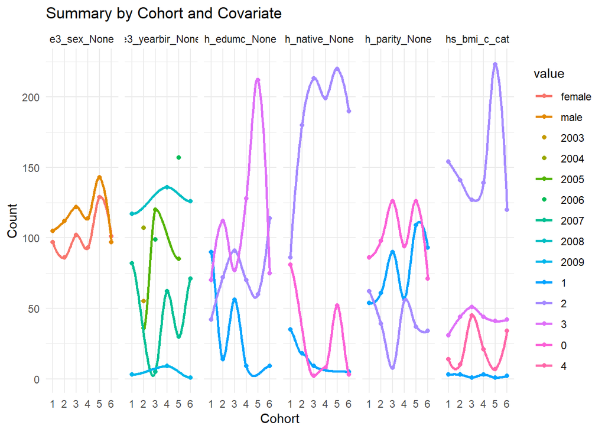

```r
# Difference by cohort
cate_cov_phe_summ = cate_cov_phe %>%
  pivot_longer(cols = -h_cohort, names_to = "covariate", values_to = "value") %>%
  group_by(h_cohort, covariate,value) %>%
  summarize(n = n(), .groups = 'drop') %>%
  ungroup()

cate_cov_phe_summ %>%
  ggplot(aes(x = h_cohort, y = n, color = value)) +
  geom_point() +
  geom_smooth(aes(group=value), method = "loess", se = FALSE) +
  facet_grid(. ~ covariate) +
  theme_minimal() +  # For a cleaner look
  labs(x = "Cohort", y = "Count", title = "Summary by Cohort and Covariate")
```

### continuous variables

```r
cont_cov_phe = cov_phe|> select(where(is.numeric))

summary_table_cov_phe <- cont_cov_phe %>%
  summarise(across(where(is.numeric), list(
    Mean = ~mean(.x, na.rm = TRUE),
    SD = ~sd(.x, na.rm = TRUE),
    Median = ~median(.x, na.rm = TRUE),
    IQR = ~IQR(.x, na.rm = TRUE)
  ))) |>
  pivot_longer(
    cols = everything(),
    names_to = c(".value", "Statistic"),
    names_pattern = "(.*)_(.*)"
  )
summary_table_cov_phe|> knitr::kable()
```

| Statistic | ID | h_mbmi_None | hs_wgtgain_None | e3_gac_None | h_age_None | hs_child_age_None | hs_c_height_None | hs_c_weight_None | e3_bw | hs_asthma | hs_zbmi_who | hs_correct_raven | hs_Gen_Tot |
| --- | --- | --- | --- | --- | --- | --- | --- | --- | --- | --- | --- | --- | --- |
| Mean | 651.0000 | 25.030708 | 13.504842 | 39.625673 | 30.795058 | 7.975708 | 1.2914643 | 28.517218 | 3389.3021 | 0.1091468 | 0.403236 | 26.28824 | 24.37672 |
| SD | 375.7107 | 5.183072 | 6.240749 | 1.708398 | 4.857010 | 1.612297 | 0.1050532 | 7.689055 | 509.9945 | 0.3119432 | 1.189894 | 6.44485 | 19.02823 |
| Median | 651.0000 | 24.023809 | 12.000000 | 40.000000 | 31.000000 | 8.032854 | 1.2800000 | 26.900000 | 3398.0000 | 0.0000000 | 0.280000 | 27.00000 | 20.00000 |
| IQR | 650.0000 | 6.077137 | 9.000000 | 2.000000 | 6.418957 | 2.420032 | 0.1560000 | 9.800000 | 640.0000 | 0.0000000 | 1.530000 | 10.00000 | 23.43750 |

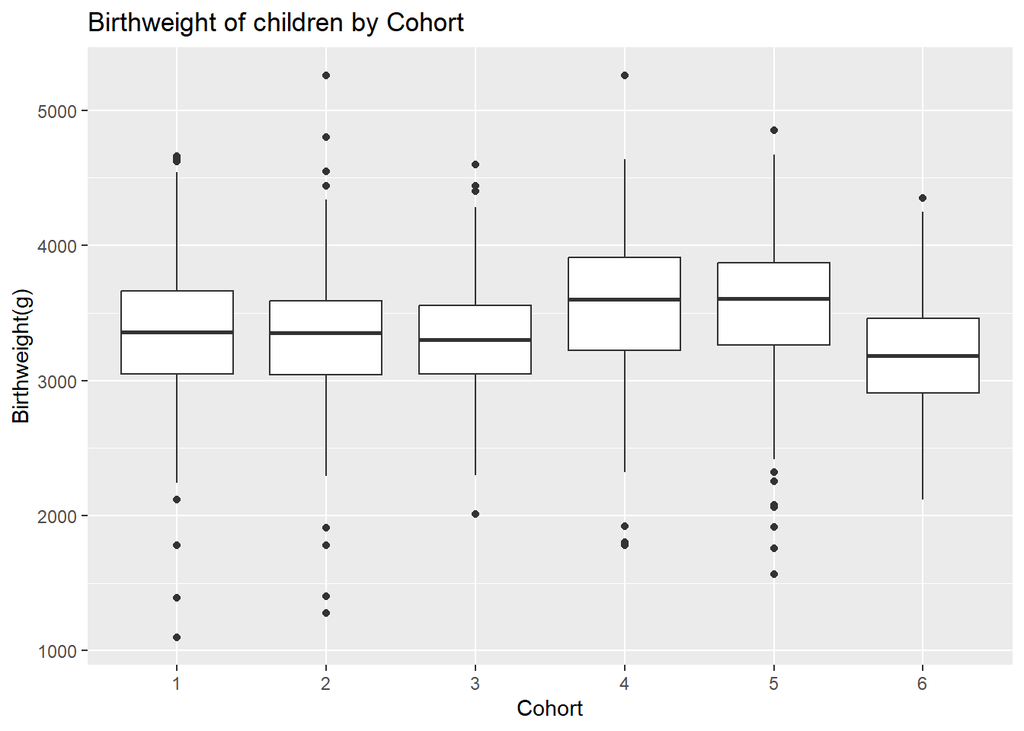

```r
# I specify the continuous variables' names in 'name' vector to add h_cohort in this dataset(I want to assess if there's difference between cohorts-especially the exposome)
name_cont_cov_phe = colnames(cont_cov_phe)[-1]
results_cov_phe = cov_phe |> select(h_cohort, any_of(name_cont_cov_phe))

results_summary_cov_phe = results_cov_phe %>%
  group_by(h_cohort) %>%
  summarize(across(where(is.numeric),
                   list(mean = ~mean(.x, na.rm = TRUE),
                        std = ~sd(.x, na.rm = TRUE))))

# Since birthweight is too large(also my outcome), I displayed it separately.
results_cov_phe |> ggplot(aes(x=h_cohort, y=e3_bw)) + geom_boxplot() +
  labs(x = "Cohort", y = "Birthweight(g)", title = "Birthweight of children by Cohort")
```

```r
results_cov_phe_nobw = results_cov_phe |> select(-e3_bw)

# difference across cohorts
results_melted_cov_phe = melt(results_cov_phe_nobw)
```

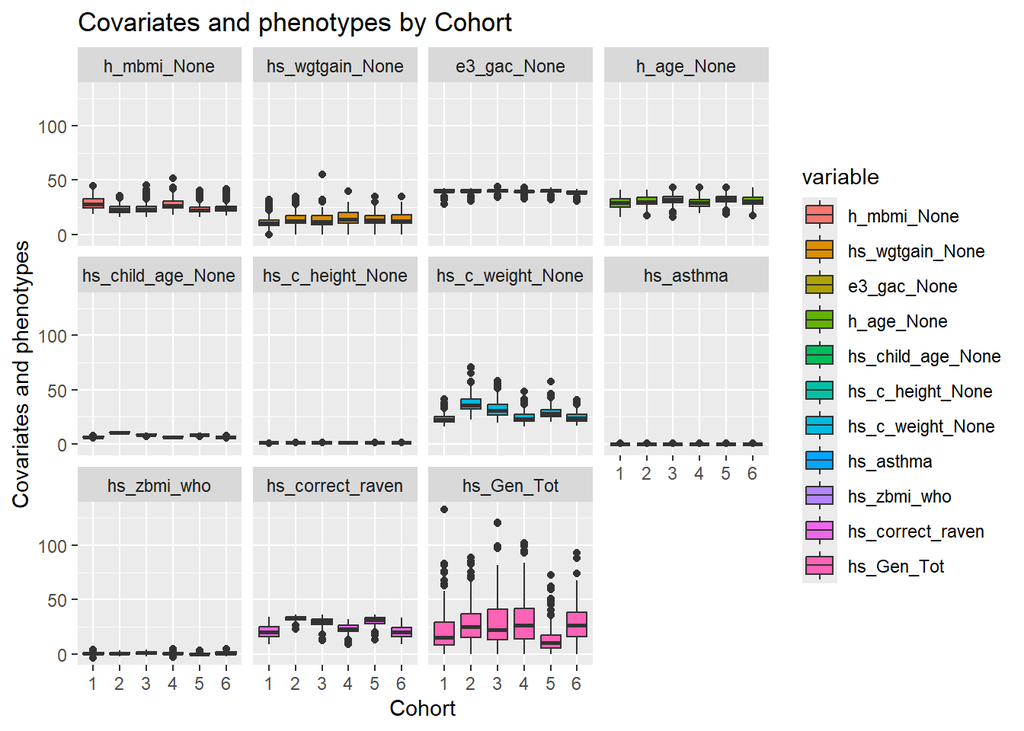

```r
results_melted_cov_phe |>
  ggplot(aes(x=h_cohort, y=value, fill=variable)) + geom_boxplot() + facet_wrap(~variable)+
  labs(x = "Cohort", y = "Covariates and phenotypes", title = "Covariates and phenotypes by Cohort")
```